# Variable Selection

Shaobo Li

In this lab, we introduce different techniques of variable selection for linear regression. Note that these methods are not limited to linear regression, we will see them again in the following lectures and labs.

#### Get the data ready

```r
library(MASS)
data(Boston)
index <- sample(nrow(Boston),nrow(Boston)*0.90)
Boston.train <- Boston[index,]
Boston.test <- Boston[-index,]
```

Recall the different models we obtained from previous lab.

```r
model0<- lm(medv~lstat, data = Boston.train)
model1<- lm(medv~., data=Boston.train)
model2<- lm(medv~. -indus -age, data=Boston.train)
```

### Compare Model Fit (AIC and BIC)

```r
AIC(model0); BIC(model0)
AIC(model1); BIC(model1)
AIC(model2); BIC(model2)
```

**Exercise**: Compare MSE, $R^2$, and MSPE of these three models.

### Forward/Backward/Stepwise Regression Using AIC

To perform the Forward/Backward/Stepwise Regression in R, we need to define the starting points:

```r
nullmodel<- lm(medv~1, data=Boston.train)
fullmodel<- lm(medv~., data=Boston.train)
```

nullmodel is the model with no varaible in it, while fullmodel is the model with every variable in it.

#### Forward Selection

```r
model.step.f<- step(nullmodel, scope=list(lower=nullmodel, upper=fullmodel), direction='forward')
```

```
## Start:  AIC=2027.3
## medv ~ 1
##
##           Df Sum of Sq   RSS    AIC
## + lstat    1   21436.6 17570 1666.4
## + rm       1   20007.0 19000 1702.0
## + ptratio  1   10669.4 28338 1883.9
## + indus    1    9390.2 29617 1904.0
## + tax      1    9110.3 29897 1908.3
## + nox      1    7177.4 31830 1936.8
## + crim     1    6491.0 32516 1946.5
## + rad      1    6009.6 32997 1953.2
## + age      1    5115.2 33892 1965.3
## + zn       1    5024.7 33982 1966.5
## + black    1    4487.1 34520 1973.7
## + dis      1    2456.2 36551 1999.7
## + chas     1    1000.6 38006 2017.5
## <none>                 39007 2027.3
##
## Step:  AIC=1666.42
## medv ~ lstat
##
##           Df Sum of Sq   RSS    AIC
## + rm       1    4159.0 13411 1545.5
## + ptratio  1    2621.7 14949 1594.9
## + dis      1     747.1 16823 1648.7
## + chas     1     560.3 17010 1653.7
## + age      1     392.3 17178 1658.2
## + tax      1     305.7 17265 1660.4
## + black    1     242.0 17328 1662.1
## + zn       1     143.1 17427 1664.7
## + indus    1     122.3 17448 1665.2
## + crim     1      95.3 17475 1666.0
## <none>                 17570 1666.4
## + rad      1      40.2 17530 1667.4
## + nox      1       5.2 17565 1668.3
##
## Step:  AIC=1545.52
## medv ~ lstat + rm
##
```

[output cut: 109 more lines]

```
##
##         Df Sum of Sq    RSS    AIC
## + crim   1    85.370 9623.4 1412.5
## <none>               9708.7 1414.5
## + indus  1    16.585 9692.1 1415.7
## + age    1     8.974 9699.7 1416.1
##
## Step:  AIC=1412.5
## medv ~ lstat + rm + ptratio + black + dis + nox + zn + chas +
##     rad + tax + crim
##
##         Df Sum of Sq    RSS    AIC
## <none>               9623.4 1412.5
## + indus  1   13.8119 9609.5 1413.8
## + age    1    9.9756 9613.4 1414.0
```

```r
summary(model.step.f)
```

```
##
## Call:
## lm(formula = medv ~ lstat + rm + ptratio + black + dis + nox +
##     zn + chas + rad + tax + crim, data = Boston.train)
##
## Residuals:
##      Min       1Q   Median       3Q      Max
## -15.1733  -2.6211  -0.5024   1.5074  26.8598
##
## Coefficients:
##               Estimate Std. Error t value Pr(>|t|)
## (Intercept)  33.919496   5.283696   6.420 3.52e-10 ***
## lstat        -0.507038   0.049369 -10.270  < 2e-16 ***
## rm            4.079537   0.421196   9.686  < 2e-16 ***
## ptratio      -0.956118   0.136902  -6.984 1.06e-11 ***
## black         0.010676   0.002719   3.926 0.000100 ***
## dis          -1.486489   0.196917  -7.549 2.53e-13 ***
## nox         -16.669751   3.587066  -4.647 4.44e-06 ***
## zn            0.043926   0.014556   3.018 0.002693 **
## chas          1.834516   0.856819   2.141 0.032813 *
## rad           0.277422   0.065290   4.249 2.62e-05 ***
## tax          -0.011830   0.003459  -3.420 0.000685 ***
## crim         -0.076977   0.038830  -1.982 0.048052 *
## ---
## Signif. codes:  0 '***' 0.001 '**' 0.01 '*' 0.05 '.' 0.1 ' ' 1
##
## Residual standard error: 4.661 on 443 degrees of freedom
## Multiple R-squared:  0.7533, Adjusted R-squared:  0.7472
## F-statistic:   123 on 11 and 443 DF,  p-value: < 2.2e-16
```

Specifying `trace=0` in the function `step()` will not print the detailed selection steps.

#### Backward Elimination

```r
model.step.b<- step(fullmodel,direction='backward')
```

```
## Start:  AIC=1415.35
## medv ~ crim + zn + indus + chas + nox + rm + age + dis + rad +
##     tax + ptratio + black + lstat
##
##           Df Sum of Sq     RSS    AIC
## - age      1     10.42  9609.5 1413.8
## - indus    1     14.26  9613.4 1414.0
## <none>                  9599.1 1415.3
## - crim     1     83.56  9682.7 1417.3
## - chas     1     84.89  9684.0 1417.4
## - zn       1    215.60  9814.7 1423.5
## - tax      1    247.70  9846.8 1425.0
## - black    1    332.71  9931.8 1428.9
## - rad      1    406.87 10006.0 1432.2
## - nox      1    478.80 10077.9 1435.5
## - dis      1    951.52 10550.6 1456.4
## - ptratio  1   1083.67 10682.8 1462.0
## - rm       1   1915.07 11514.2 1496.1
## - lstat    1   2158.04 11757.2 1505.6
##
## Step:  AIC=1413.85
## medv ~ crim + zn + indus + chas + nox + rm + dis + rad + tax +
##     ptratio + black + lstat
##
##           Df Sum of Sq     RSS    AIC
## - indus    1     13.81  9623.4 1412.5
## <none>                  9609.5 1413.8
## - crim     1     82.60  9692.1 1415.7
## - chas     1     88.61  9698.2 1416.0
## - zn       1    208.65  9818.2 1421.6
## - tax      1    245.36  9854.9 1423.3
## - black    1    340.18  9949.7 1427.7
## - rad      1    399.08 10008.6 1430.4
## - nox      1    475.63 10085.2 1433.8
## - ptratio  1   1073.35 10682.9 1460.0
## - dis      1   1146.77 10756.3 1463.1
## - rm       1   2050.47 11660.0 1499.8
## - lstat    1   2303.38 11912.9 1509.6
##
## Step:  AIC=1412.5
## medv ~ crim + zn + chas + nox + rm + dis + rad + tax + ptratio +
##     black + lstat
##
##           Df Sum of Sq     RSS    AIC
## <none>                  9623.4 1412.5
## - crim     1     85.37  9708.7 1414.5
## - chas     1     99.58  9722.9 1415.2
## - zn       1    197.84  9821.2 1419.8
## - tax      1    254.06  9877.4 1422.4
## - black    1    334.80  9958.2 1426.1
## - rad      1    392.20 10015.6 1428.7
## - nox      1    469.14 10092.5 1432.2
## - ptratio  1   1059.56 10682.9 1458.0
## - dis      1   1237.88 10861.2 1465.6
## - rm       1   2037.87 11661.2 1497.9
## - lstat    1   2291.36 11914.7 1507.7
```

Note, we don’t need to specify `scope` in the backward selection method, because you have specified the largest model, and it will automatically try to reduce it.

#### Stepwise Selection (Output Omitted)

```r
model.step.s<- step(nullmodel, scope=list(lower=nullmodel, upper=fullmodel), direction='both')
```

#### Exercise

1. Comparing in-sample and out-of-sample performance between these different models.
2. Conduct 10-fold cross validation on the full sample and compare the CV scores.
3. By default, `step()` uses AIC as the selection criterion. You can use BIC by specifying `k=log(n)`, where n is the training sample size. Please use BIC to run these three approaches and see if you obtain different models.

Back to top

### Best Subset Regression

The ‘leaps’ package provides procedures for best subset regression.

```r
install.packages('leaps')
```

```r
library(leaps)
```

Which subset of variables should you include in order to minimize BIC?

```r
#regsubsets only takes data frame as input
model.subset<- regsubsets(medv~.,data=Boston.train, nbest=2, nvmax = 13)
sum.subset<- summary(model.subset)
sum.subset
```

```
## Subset selection object
## Call: regsubsets.formula(medv ~ ., data = Boston.train, nbest = 2,
##     nvmax = 13)
## 13 Variables  (and intercept)
##         Forced in Forced out
## crim        FALSE      FALSE
## zn          FALSE      FALSE
## indus       FALSE      FALSE
## chas        FALSE      FALSE
## nox         FALSE      FALSE
## rm          FALSE      FALSE
## age         FALSE      FALSE
## dis         FALSE      FALSE
## rad         FALSE      FALSE
## tax         FALSE      FALSE
## ptratio     FALSE      FALSE
## black       FALSE      FALSE
## lstat       FALSE      FALSE
## 2 subsets of each size up to 13
## Selection Algorithm: exhaustive
##           crim zn  indus chas nox rm  age dis rad tax ptratio black lstat
## 1  ( 1 )  " "  " " " "   " "  " " " " " " " " " " " " " "     " "   "*"
## 1  ( 2 )  " "  " " " "   " "  " " "*" " " " " " " " " " "     " "   " "
## 2  ( 1 )  " "  " " " "   " "  " " "*" " " " " " " " " " "     " "   "*"
## 2  ( 2 )  " "  " " " "   " "  " " " " " " " " " " " " "*"     " "   "*"
## 3  ( 1 )  " "  " " " "   " "  " " "*" " " " " " " " " "*"     " "   "*"
## 3  ( 2 )  " "  " " " "   " "  " " "*" " " " " " " " " " "     "*"   "*"
## 4  ( 1 )  " "  " " " "   " "  " " "*" " " " " " " " " "*"     "*"   "*"
## 4  ( 2 )  " "  " " " "   " "  " " "*" " " "*" " " " " "*"     " "   "*"
## 5  ( 1 )  " "  " " " "   " "  "*" "*" " " "*" " " " " "*"     " "   "*"
## 5  ( 2 )  " "  " " " "   " "  " " "*" " " "*" " " " " "*"     "*"   "*"
## 6  ( 1 )  " "  " " " "   " "  "*" "*" " " "*" " " " " "*"     "*"   "*"
## 6  ( 2 )  " "  " " " "   "*"  "*" "*" " " "*" " " " " "*"     " "   "*"
## 7  ( 1 )  " "  "*" " "   " "  "*" "*" " " "*" " " " " "*"     "*"   "*"
## 7  ( 2 )  " "  " " " "   "*"  "*" "*" " " "*" " " " " "*"     "*"   "*"
## 8  ( 1 )  " "  " " " "   " "  "*" "*" " " "*" "*" "*" "*"     "*"   "*"
## 8  ( 2 )  " "  "*" " "   "*"  "*" "*" " " "*" " " " " "*"     "*"   "*"
## 9  ( 1 )  " "  "*" " "   " "  "*" "*" " " "*" "*" "*" "*"     "*"   "*"
## 9  ( 2 )  " "  " " " "   "*"  "*" "*" " " "*" "*" "*" "*"     "*"   "*"
## 10  ( 1 ) " "  "*" " "   "*"  "*" "*" " " "*" "*" "*" "*"     "*"   "*"
## 10  ( 2 ) "*"  "*" " "   " "  "*" "*" " " "*" "*" "*" "*"     "*"   "*"
## 11  ( 1 ) "*"  "*" " "   "*"  "*" "*" " " "*" "*" "*" "*"     "*"   "*"
## 11  ( 2 ) " "  "*" "*"   "*"  "*" "*" " " "*" "*" "*" "*"     "*"   "*"
## 12  ( 1 ) "*"  "*" "*"   "*"  "*" "*" " " "*" "*" "*" "*"     "*"   "*"
## 12  ( 2 ) "*"  "*" " "   "*"  "*" "*" "*" "*" "*" "*" "*"     "*"   "*"
## 13  ( 1 ) "*"  "*" "*"   "*"  "*" "*" "*" "*" "*" "*" "*"     "*"   "*"
```

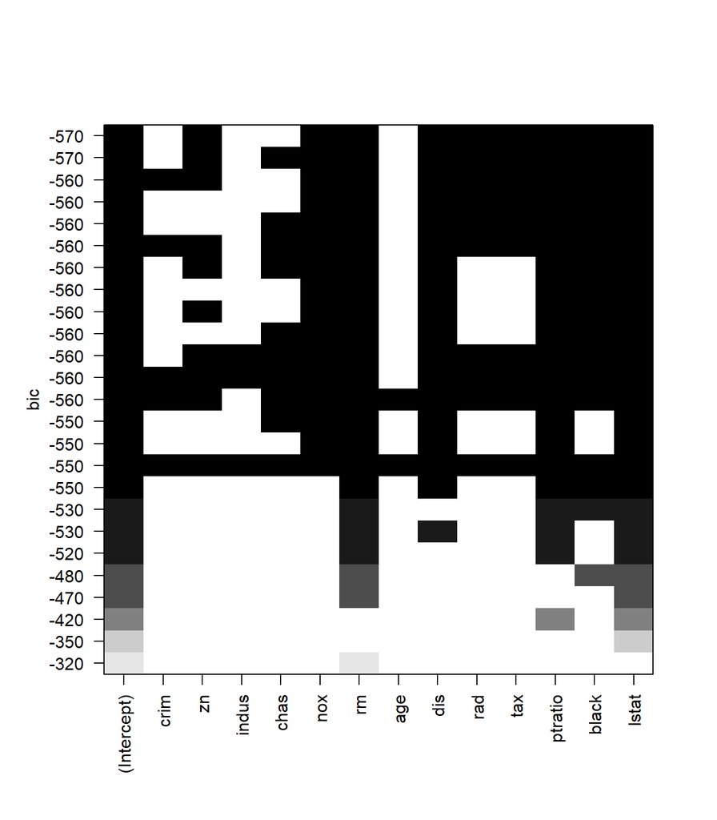

```r
plot(model.subset, scale="bic")
```

Each row represents a model. Black indicates that a variable is included in the model, while white indicates that it is not. The argument scale = “Cp”, “adjr2”, “r2” or “bic”.

We can get exactly the model we want.

```r
# extract certain criteria for all evaluated models
sum.subset$bic
```

```
##  [1] -350.6336 -315.0427 -467.4120 -418.0382 -519.0167 -481.9543 -531.2709
##  [8] -528.4859 -552.3470 -546.4399 -562.7728 -553.3531 -562.6599 -562.5325
## [15] -564.7426 -562.8874 -566.4702 -563.5266 -565.4527 -564.7870 -563.3509
## [22] -560.1103 -557.8841 -557.7025 -552.2576
```

```r
# which one is the best?
which.min(sum.subset$bic)
```

```
## [1] 17
```

```r
# get the model (selected variables)
coef(model.subset, id=which.min(sum.subset$bic))
```

```
##  (Intercept)           zn          nox           rm          dis          rad
##  32.72285076   0.04058528 -15.32511469   4.19088991  -1.45468725   0.24422757
##          tax      ptratio        black        lstat
##  -0.01217974  -0.96857137   0.01200204  -0.52644950
```

#### Exercise:

1. Obtain the best model in terms of adjusted R square. What variables are selected?
2. Is it the same as the one based on BIC? If not, compute MSPE for both models and compare.